# ANÁLISIS DE LA CORRELACIÓN ENTRE LA INFLACIÓN Y LA PERCEPCIÓN DE CORRUPCIÓN

### Coeficiente de Correlación de Spearman’s Rank

#### ¿Por qué este coeficiente?

Utilizo este método debido a que los datos no siguen una distribución normal y hay valores extremos.

#### Calculo

```r
# Calcular el coeficiente de correlación de Spearman
corr_test <- cor.test(df_melted$inflation, df_melted$score,
                      method = "spearman", use = "complete.obs",
                      exact = FALSE)
# Nota:
# Nota: Me saltaba el error de que no era posible calcular el coeficiente exacto, por lo que lo he puesto en FALSE, es decir, que no se calcula exactamente.

# Definir el nivel de significancia
alpha <- 0.05

# Mostrar los resultados
cat("Coeficiente de Correlación de Spearman's Rank:", corr_test$estimate, "\n")
```

```
## Coeficiente de Correlación de Spearman's Rank: -0.4098749
```

```r
if (corr_test$p.value < alpha) {
  cat("p-valor:", corr_test$p.value, ", Se rechaza la hipótesis nula\n")
} else {
  cat("p-valor:", corr_test$p.value, ", No se rechaza la hipótesis nula\n")
}
```

```
## p-valor: 6.571181e-165 , Se rechaza la hipótesis nula
```

#### Resultados:

El Coeficiente de Correlación de Spearman’s Rank calculado entre las columnas `inflation` y `score` ha arrojado los siguientes resultados:

- **Coeficiente de Correlación de Spearman’s Rank**: -0.4098749
- **p-valor**: 6.571181e-165

#### Interpretación:

1. **Coeficiente de Correlación**:
   - El valor del coeficiente de correlación de Spearman es -0.4098749, lo que indica una correlación negativa moderada entre la inflación y la puntuación de corrupción.
   - Esto sugiere que, en general, a medida que aumenta la inflación tambien existe una mayor percepción de la corrupción.
2. **p-valor**:
   - El **p-valor** obtenido es extremadamente bajo (6.571181e-165), lo que es mucho menor que el nivel de significancia comúnmente utilizado (**α** = 0.05). Esto significa que podemos rechazar la hipótesis nula de que no existe correlación entre la inflación y la puntuación de corrupción. En otras palabras, la correlación observada es estadísticamente significativa.

En resumen, los resultados del Coeficiente de Correlación de Spearman’s Rank sugieren que existe una correlación negativa significativa entre la inflación y la puntuación de corrupción en los datos analizados.

### Visualización de la Correlación e Inflación mediana por Año

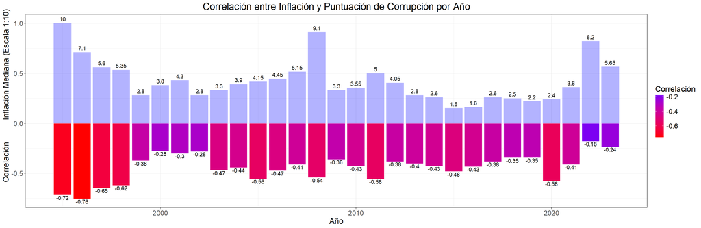

```r
# Calcular la correlación entre 'inflation' y 'score' por año
correlation_by_year <- df_melted %>%
    group_by(year) %>%
    summarise(correlation = cor(inflation, score, method = "spearman", use = "complete.obs"))
# Crear un barplot de la correlación por año
ggplot(correlation_by_year, aes(x = year)) +
    geom_bar(aes(y = correlation, fill = correlation), stat = "identity", color = "white") +

    scale_fill_gradient2(low = "#ff0000", high = "#77ff00", mid = "#6600ff", midpoint = -0.15) +

    geom_bar(data = df_melted %>% group_by(year) %>% summarise(median_inflation = median(inflation, na.rm = TRUE)),
              aes(y = median_inflation / 10), stat = "identity", fill = 'blue', alpha = 0.3) +

        geom_text(data = df_melted %>% group_by(year) %>% summarise(median_inflation = median(inflation, na.rm = TRUE)),
              aes(y = median_inflation / 10, label = round(median_inflation, 2)), vjust = -0.5, size = 4, color = "#000000") +

    geom_text(aes(y = correlation, label = round(correlation, 2)), vjust = 1.1, size = 4) +

    scale_color_brewer(palette = "Dark2") +

    labs(title = "Correlación entre Inflación y Puntuación de Corrupción por Año",
         x = "Año",
         y = "              Correlación          Inflación Mediana (Escala 1:10)",
         fill = "Correlación")
```

**Nota**: El CPI promedio anual no tiene apenas varianza, situandose entre 40 y 43,5 puntos salvo en 1995 que llegó a alcanzar los 60 puntos, que fueron bajando paulatinamente hasta el año 2003 donde comienza la estabilidad.